# Simulation SIG

Hanne Oberman

7-10-2021

# Data Generating Mechanism

$${\Sigma} = \left[ \begin{array}{cccccccccc}
1.05 & -0.12 & 0.04 & -0.29 & 0.29 & -0.17 & 0.01 & 0 & -0.01 & -0.07 \\
-0.12 & 1.08 & -0.31 & 0.26 & 0.08 & -0.03 & -0.04 & -0.11 & -0.17 & 0.3 \\
0.04 & -0.31 & 1.08 & -0.19 & 0.01 & -0.29 & 0.2 & 0.07 & -0.18 & -0.15 \\
-0.29 & 0.26 & -0.19 & 1.07 & -0.2 & 0 & -0.12 & 0.01 & -0.19 & -0.04 \\
0.29 & 0.08 & 0.01 & -0.2 & 1.08 & -0.25 & -0.14 & 0.02 & 0.15 & -0.32 \\
-0.17 & -0.03 & -0.29 & 0 & -0.25 & 1.08 & -0.13 & -0.04 & -0.29 & 0.01 \\
0.01 & -0.04 & 0.2 & -0.12 & -0.14 & -0.13 & 1.04 & -0.16 & -0.17 & 0.18 \\
0 & -0.11 & 0.07 & 0.01 & 0.02 & -0.04 & -0.16 & 1.02 & 0.1 & -0.19 \\
-0.01 & -0.17 & -0.18 & -0.19 & 0.15 & -0.29 & -0.17 & 0.1 & 1.08 & 0.15 \\
-0.07 & 0.3 & -0.15 & -0.04 & -0.32 & 0.01 & 0.18 & -0.19 & 0.15 & 1.08
\end{array} \right]$$
There is a deterministic relationship between the predictor space $\bf{X}$ and the binary outcome $Y$ through the logit link function,

$$\text{logit}(Pr(Y = 1)) = \beta_o + \beta \times \bf{X} + \beta^* \times \mathrm{X_1} \times \bf{X} + \varepsilon,$$

$$\begin{array}{lllccccccccc}
\beta &= &[&-0.27 &0.53 &-0.97 &-0.05 &0.62 &-0.52 &0.53 &-0.61 &0.17 &-0.55&]\\
\beta^* &= &[&0.06 &0.04 &-0.02 &-0.02 &-0.06 &-0.05 &0.04 &0.05 &0.01 &-0.07&]
\end{array}$$
With an intercept of $\beta_0 = -3$, this yields an incidence in $Y$ of ~15%.

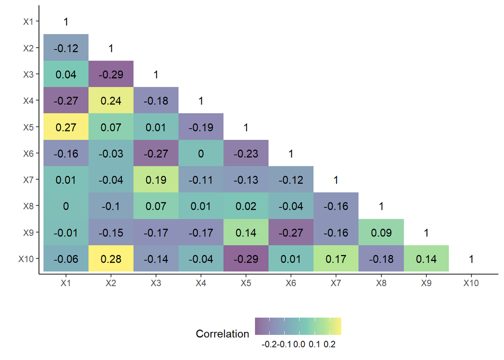

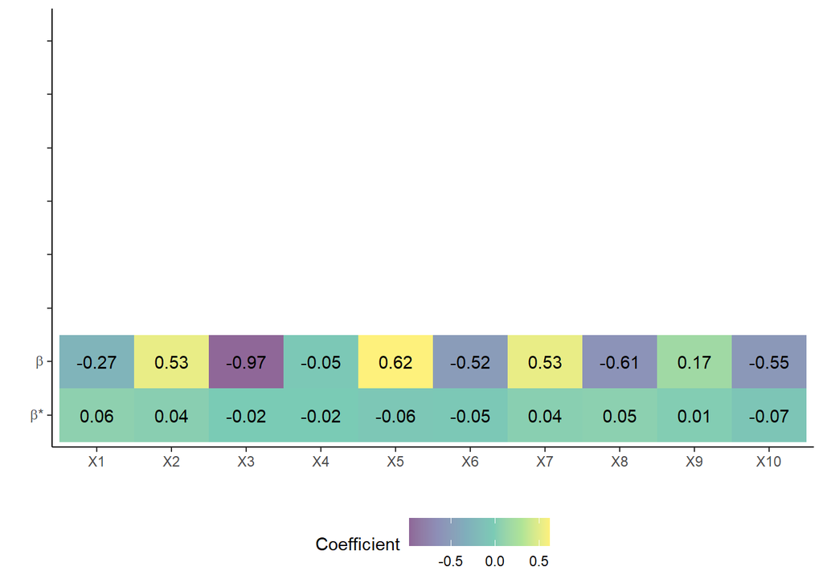

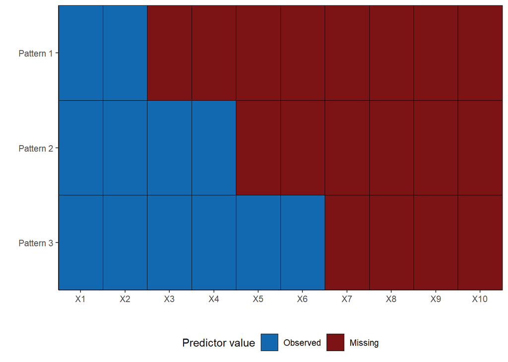

# Reference Performance

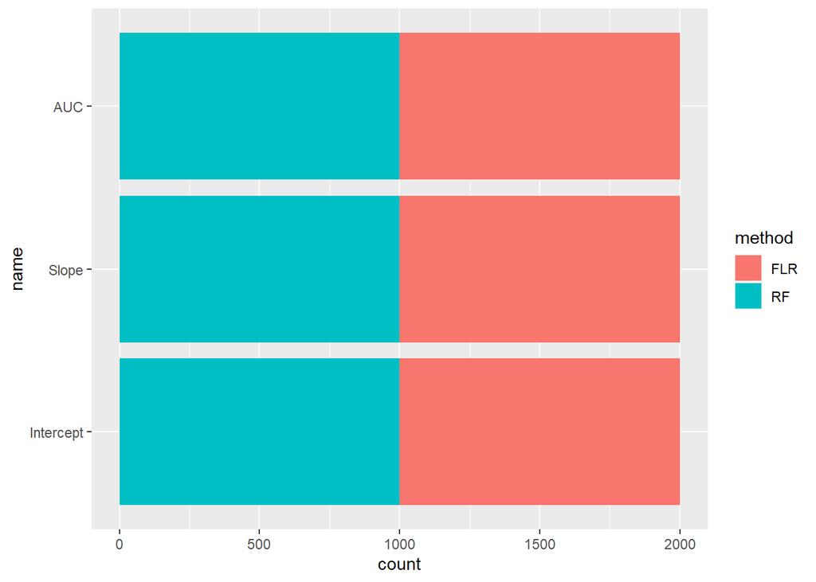

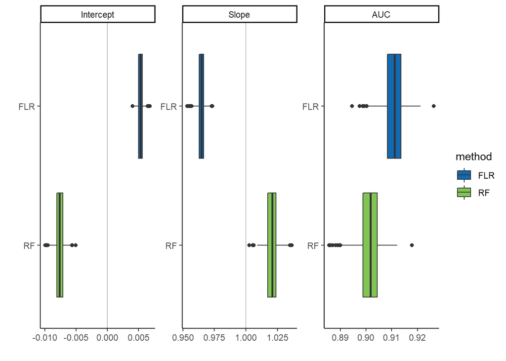

On complete data, the flexible logistics regression and random forest prediction models have equivalent calibration:

- FLR intercept closer to 0 than RF (0.005, -0.008, respectively);
- FLR slope further from 1 than RF (0.965, 1.021, respectively).

The flexible logistic regression prediction model has somewhat better discrimination than the random forest:

- FLR C-index higher than RF (0.911, 0.901, respectively).

# Simulation Results

## Calibration

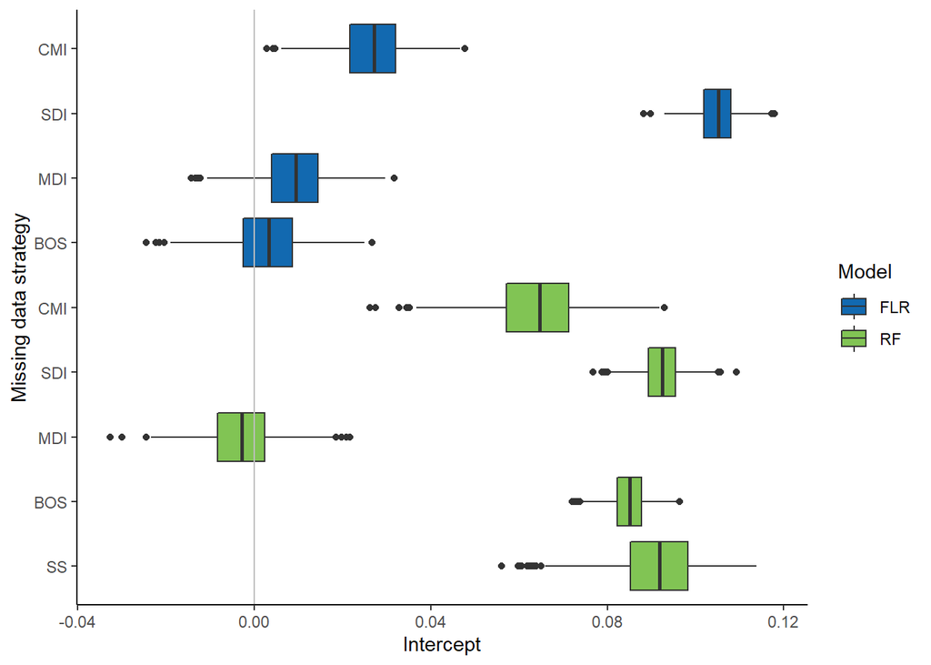

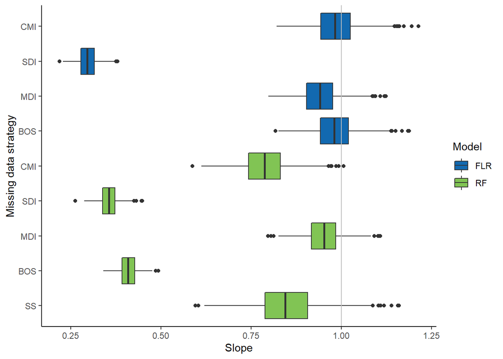

Aim: Intercept should be zero, slope should be one.

Summary:

- Best performance in terms of intercept: BOS+FLR, MDI+RF, MDI+FLR
- Worst performance in terms of intercept: SDI+FLR, SS+RF (wide range), SDI+RF, BOS+RF (CMI+RF = mixed bag)
- Best performance in terms of slope: BOS+FLR, CMI+FLR, MDI+RF and MDI+FLR
- Terrible performance in terms of slope: SDI+FLR, SDI+RF, BOS+RF

## AUC

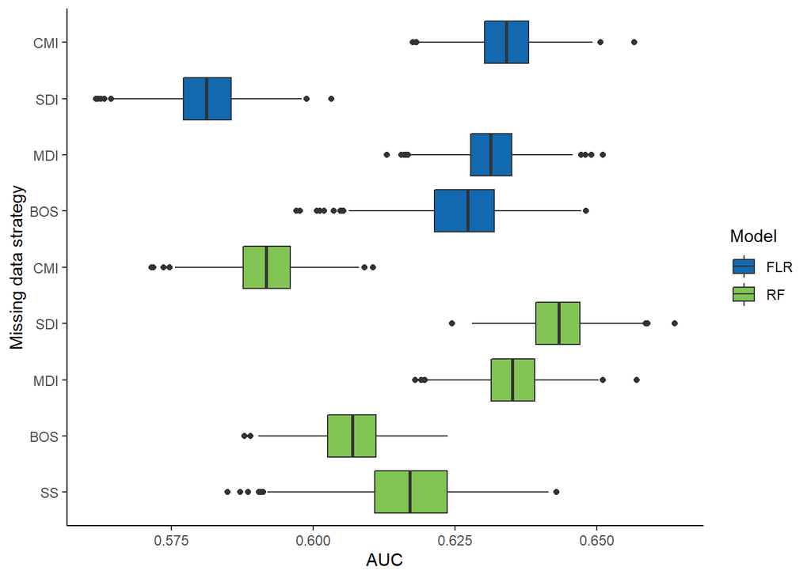

Aim: As close to one as possible. Method with the highest AUC has the best discrimination between patients with and without the outcome (Y).

## MAE

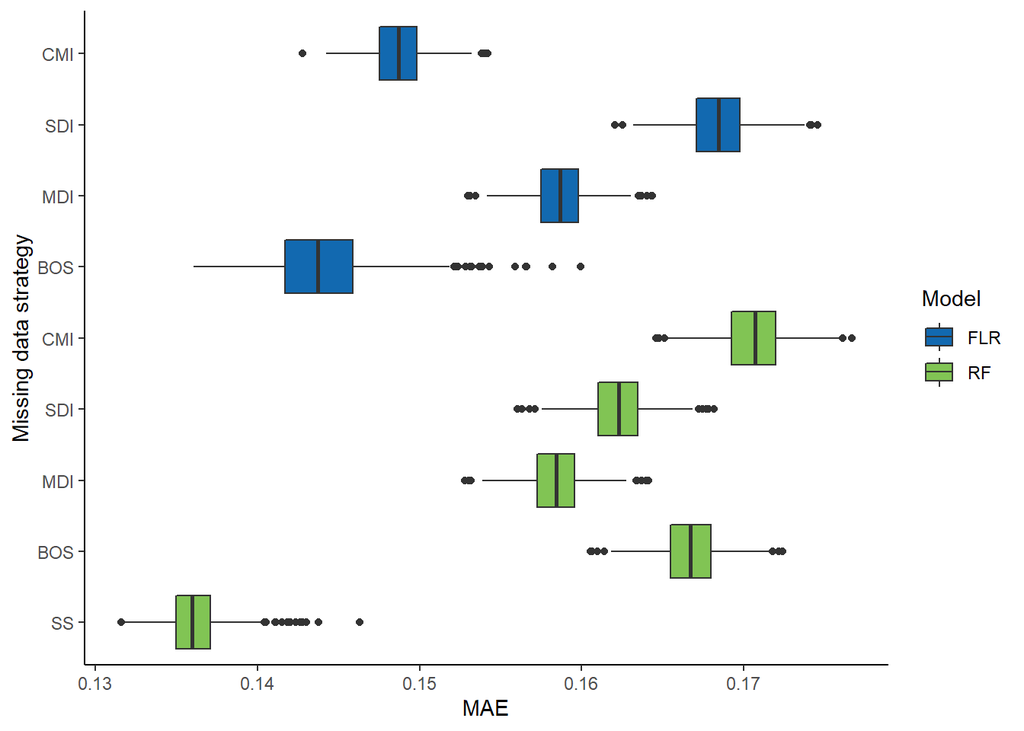

Aim: As close to zero as possible. Method with the lowest MAE has the best approximation of the true probability of Y.

Summary:

- Best performance in terms of MAE: SS+RF(???), BOS+FLR, CMI+FLR
- Worst performance in terms of MAE: CMI+RF, SDI+FLR,, BOS+RF

## RMSE

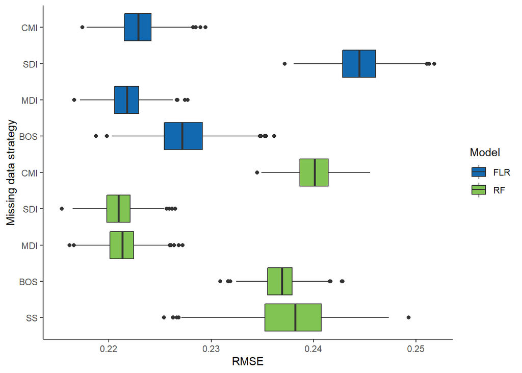

Aim: As close to zero as possible. Method with the lowest RMSE has best recovered the original probability of Y.

Summary:

- Best performance in terms of RMSE: SDI+RF (???), MDI+BOS, MDI+FLR, CMI+FLR (BOS+FLR = mixed bag)
- Worst performance in terms of RMSE: SDI+FLR, CMI+RF, SS+RF (very wide range) and BOS+RF

## Brier score

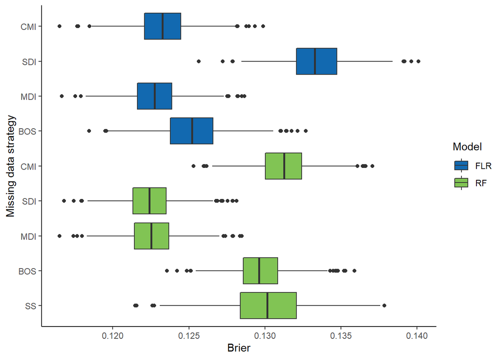

Aim: As close to zero as possible. Method with the lowest Brier score has best recovered the original observed Y.

Summary:

- Best performance in terms of Brier score: SDI+RF, MDI+RF, MDI+FLR, CMI+FLR
- Worst performance in terms of Brier score: SDI+FLR, CMI+RF, SS+RF (wide range) and BOS+RF

## Full Figure

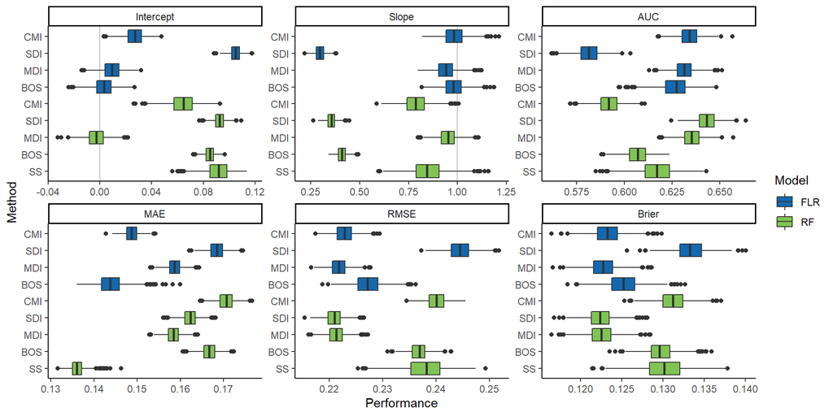

## Summary Table

| Model | Strategy | Intercept | Slope | AUC | RMSE | Brier | MAE |
| --- | --- | --- | --- | --- | --- | --- | --- |
| FLR | CMI | 0.027 | 0.984 | 0.634 | 0.223 | 0.123 | 0.149 |
| FLR | SDI | 0.105 | 0.297 | 0.581 | 0.244 | 0.133 | 0.168 |
| FLR | MDI | 0.009 | 0.940 | 0.631 | 0.222 | 0.123 | 0.159 |
| FLR | BOS | 0.003 | 0.981 | 0.627 | 0.227 | 0.125 | 0.144 |
| FLR | SS | NA | NA | NA | NA | NA | NA |
| RF | CMI | 0.064 | 0.788 | 0.592 | 0.240 | 0.131 | 0.171 |
| RF | SDI | 0.092 | 0.355 | 0.643 | 0.221 | 0.122 | 0.162 |
| RF | MDI | -0.003 | 0.951 | 0.635 | 0.221 | 0.123 | 0.158 |
| RF | BOS | 0.085 | 0.410 | 0.607 | 0.237 | 0.130 | 0.167 |
| RF | SS | 0.091 | 0.849 | 0.617 | 0.238 | 0.130 | 0.136 |